# Risk Factor Analysis

## Outcome Variable

**Outcome Variable:** stunted

## Predictor Variables

**Intervention Variable:** nhh

**Adjustment Set:**

- arm
- W_mage
- meducyrs
- feducyrs
- hhwealth_quart
- W_mhtcm
- W_mwtkg
- W_mbmi
- W_nrooms
- cleanck
- impfloor
- impsan
- safeh20
- delta_W_mage
- delta_meducyrs
- delta_feducyrs
- delta_hhwealth_quart
- delta_W_mhtcm
- delta_W_mwtkg
- delta_W_mbmi
- delta_W_nrooms
- delta_cleanck
- delta_impfloor
- delta_impsan
- delta_safeh20

## Stratifying Variables

The analysis was stratified on these variable(s):

- agecat
- studyid
- country

## Data Summary

| agecat | studyid | country | nhh | stunted | n_cell | n |
| --- | --- | --- | --- | --- | --- | --- |
| 6 months | ki1000108-IRC | INDIA | 3 or less | 0 | 44 | 407 |
| 6 months | ki1000108-IRC | INDIA | 3 or less | 1 | 14 | 407 |
| 6 months | ki1000108-IRC | INDIA | 4-5 | 0 | 116 | 407 |
| 6 months | ki1000108-IRC | INDIA | 4-5 | 1 | 42 | 407 |
| 6 months | ki1000108-IRC | INDIA | 6-7 | 0 | 81 | 407 |
| 6 months | ki1000108-IRC | INDIA | 6-7 | 1 | 25 | 407 |
| 6 months | ki1000108-IRC | INDIA | 8+ | 0 | 66 | 407 |
| 6 months | ki1000108-IRC | INDIA | 8+ | 1 | 19 | 407 |
| 24 months | ki1000108-IRC | INDIA | 3 or less | 0 | 39 | 409 |
| 24 months | ki1000108-IRC | INDIA | 3 or less | 1 | 19 | 409 |
| 24 months | ki1000108-IRC | INDIA | 4-5 | 0 | 88 | 409 |
| 24 months | ki1000108-IRC | INDIA | 4-5 | 1 | 70 | 409 |
| 24 months | ki1000108-IRC | INDIA | 6-7 | 0 | 66 | 409 |
| 24 months | ki1000108-IRC | INDIA | 6-7 | 1 | 41 | 409 |
| 24 months | ki1000108-IRC | INDIA | 8+ | 0 | 46 | 409 |
| 24 months | ki1000108-IRC | INDIA | 8+ | 1 | 40 | 409 |
| Birth | ki1000108-IRC | INDIA | 3 or less | 0 | 51 | 388 |
| Birth | ki1000108-IRC | INDIA | 3 or less | 1 | 3 | 388 |
| Birth | ki1000108-IRC | INDIA | 4-5 | 0 | 128 | 388 |
| Birth | ki1000108-IRC | INDIA | 4-5 | 1 | 22 | 388 |
| Birth | ki1000108-IRC | INDIA | 6-7 | 0 | 89 | 388 |
| Birth | ki1000108-IRC | INDIA | 6-7 | 1 | 14 | 388 |
| Birth | ki1000108-IRC | INDIA | 8+ | 0 | 75 | 388 |
| Birth | ki1000108-IRC | INDIA | 8+ | 1 | 6 | 388 |
| 6 months | ki1000304b-SAS-FoodSuppl | INDIA | 3 or less | 0 | 23 | 380 |
| 6 months | ki1000304b-SAS-FoodSuppl | INDIA | 3 or less | 1 | 10 | 380 |
| 6 months | ki1000304b-SAS-FoodSuppl | INDIA | 4-5 | 0 | 96 | 380 |
| 6 months | ki1000304b-SAS-FoodSuppl | INDIA | 4-5 | 1 | 70 | 380 |
| 6 months | ki1000304b-SAS-FoodSuppl | INDIA | 6-7 | 0 | 65 | 380 |
| 6 months | ki1000304b-SAS-FoodSuppl | INDIA | 6-7 | 1 | 50 | 380 |

[output cut: 82 more lines]

The following strata were considered:

- agecat: 24 months, studyid: ki1000108-IRC, country: INDIA
- agecat: 24 months, studyid: ki1017093-NIH-Birth, country: BANGLADESH
- agecat: 24 months, studyid: ki1017093b-PROVIDE, country: BANGLADESH
- agecat: 24 months, studyid: ki1017093c-NIH-Crypto, country: BANGLADESH
- agecat: 24 months, studyid: ki1148112-LCNI-5, country: MALAWI
- agecat: 6 months, studyid: ki1000108-IRC, country: INDIA
- agecat: 6 months, studyid: ki1000304b-SAS-FoodSuppl, country: INDIA
- agecat: 6 months, studyid: ki1017093-NIH-Birth, country: BANGLADESH
- agecat: 6 months, studyid: ki1017093b-PROVIDE, country: BANGLADESH
- agecat: 6 months, studyid: ki1017093c-NIH-Crypto, country: BANGLADESH
- agecat: 6 months, studyid: ki1148112-LCNI-5, country: MALAWI
- agecat: Birth, studyid: ki1000108-IRC, country: INDIA
- agecat: Birth, studyid: ki1017093-NIH-Birth, country: BANGLADESH
- agecat: Birth, studyid: ki1017093c-NIH-Crypto, country: BANGLADESH

### Dropped Strata

Some strata were dropped due to rare outcomes:

- agecat: Birth, studyid: ki1000108-IRC, country: INDIA
- agecat: Birth, studyid: ki1017093-NIH-Birth, country: BANGLADESH
- agecat: Birth, studyid: ki1017093c-NIH-Crypto, country: BANGLADESH

## Methods Detail

We’re interested in the causal parameters $E[Y_a]$ for all values of $a \in \mathcal{A}$. These parameters represent the mean outcome if, possibly contrary to fact, we intervened to set all units to have $A=a$. Under the randomization and positivity assumptions, these are identified by the statistical parameters $\psi_a=E_W[E_{Y|A,W}(Y|A=a,W)]$. In addition, we’re interested in the mean of $Y$, $E[Y]$ under no intervention (the observed mean). We will estimate these parameters by using SuperLearner to fit the relevant likelihood factors – $E_{Y|A,W}(Y|A=a,W)$ and $p(A=a|W)$, and then updating our likelihood fit using a joint TMLE.

For unadjusted analyses ($W=\{\}$), initial likelihoods were estimated using Lrnr_glm to estimate the simple $E(Y|A)$ and Lrnr_mean to estimate $p(A)$. For adjusted analyses, a small library containing Lrnr_glmnet, Lrnr_xgboost, and Lrnr_mean was used.

Having estimated these parameters, we will then use the delta method to estimate relative risks and attributable risks relative to a prespecified baseline level of $A$.

# Results Detail

## Results Plots

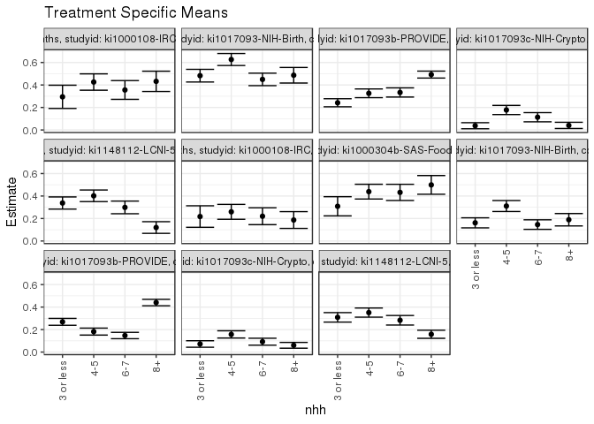

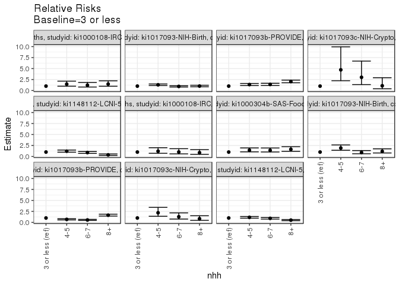

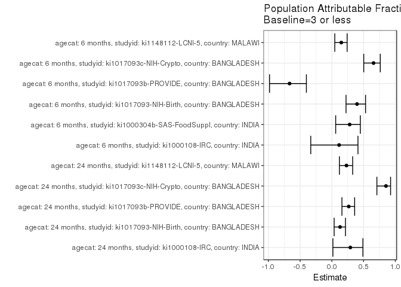

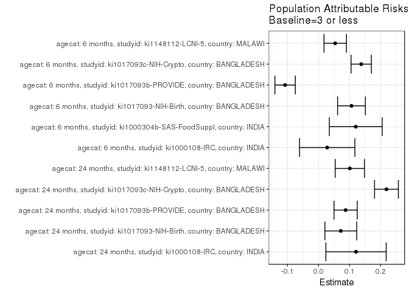

## Results Table

### Parameter: TSM

| agecat | studyid | country | intervention_level | baseline_level | estimate | ci_lower | ci_upper |
| --- | --- | --- | --- | --- | --- | --- | --- |
| 6 months | ki1000108-IRC | INDIA | 3 or less | NA | 0.2176277 | 0.1218112 | 0.3134443 |
| 6 months | ki1000108-IRC | INDIA | 4-5 | NA | 0.2596797 | 0.1934717 | 0.3258878 |
| 6 months | ki1000108-IRC | INDIA | 6-7 | NA | 0.2204138 | 0.1454312 | 0.2953963 |
| 6 months | ki1000108-IRC | INDIA | 8+ | NA | 0.1867318 | 0.1121758 | 0.2612878 |
| 6 months | ki1000304b-SAS-FoodSuppl | INDIA | 3 or less | NA | 0.3087671 | 0.2233863 | 0.3941479 |
| 6 months | ki1000304b-SAS-FoodSuppl | INDIA | 4-5 | NA | 0.4390474 | 0.3733724 | 0.5047223 |
| 6 months | ki1000304b-SAS-FoodSuppl | INDIA | 6-7 | NA | 0.4324620 | 0.3603858 | 0.5045382 |
| 6 months | ki1000304b-SAS-FoodSuppl | INDIA | 8+ | NA | 0.4989852 | 0.4158124 | 0.5821580 |
| 6 months | ki1017093-NIH-Birth | BANGLADESH | 3 or less | NA | 0.1617995 | 0.1170896 | 0.2065093 |
| 6 months | ki1017093-NIH-Birth | BANGLADESH | 4-5 | NA | 0.3110194 | 0.2623135 | 0.3597252 |
| 6 months | ki1017093-NIH-Birth | BANGLADESH | 6-7 | NA | 0.1461374 | 0.1037562 | 0.1885187 |
| 6 months | ki1017093-NIH-Birth | BANGLADESH | 8+ | NA | 0.1892642 | 0.1341759 | 0.2443525 |
| 6 months | ki1017093b-PROVIDE | BANGLADESH | 3 or less | NA | 0.2687510 | 0.2381447 | 0.2993574 |
| 6 months | ki1017093b-PROVIDE | BANGLADESH | 4-5 | NA | 0.1820413 | 0.1510213 | 0.2130613 |
| 6 months | ki1017093b-PROVIDE | BANGLADESH | 6-7 | NA | 0.1471336 | 0.1187719 | 0.1754953 |
| 6 months | ki1017093b-PROVIDE | BANGLADESH | 8+ | NA | 0.4403870 | 0.4115157 | 0.4692583 |
| 6 months | ki1017093c-NIH-Crypto | BANGLADESH | 3 or less | NA | 0.0720124 | 0.0431443 | 0.1008806 |
| 6 months | ki1017093c-NIH-Crypto | BANGLADESH | 4-5 | NA | 0.1571394 | 0.1249629 | 0.1893158 |
| 6 months | ki1017093c-NIH-Crypto | BANGLADESH | 6-7 | NA | 0.0922336 | 0.0613130 | 0.1231542 |
| 6 months | ki1017093c-NIH-Crypto | BANGLADESH | 8+ | NA | 0.0602103 | 0.0344192 | 0.0860015 |
| 6 months | ki1148112-LCNI-5 | MALAWI | 3 or less | NA | 0.3088012 | 0.2667289 | 0.3508735 |
| 6 months | ki1148112-LCNI-5 | MALAWI | 4-5 | NA | 0.3510776 | 0.3104299 | 0.3917254 |
| 6 months | ki1148112-LCNI-5 | MALAWI | 6-7 | NA | 0.2827407 | 0.2402603 | 0.3252211 |
| 6 months | ki1148112-LCNI-5 | MALAWI | 8+ | NA | 0.1582670 | 0.1223828 | 0.1941511 |
| 24 months | ki1000108-IRC | INDIA | 3 or less | NA | 0.2946341 | 0.1913103 | 0.3979580 |
| 24 months | ki1000108-IRC | INDIA | 4-5 | NA | 0.4262069 | 0.3534189 | 0.4989948 |
| 24 months | ki1000108-IRC | INDIA | 6-7 | NA | 0.3556032 | 0.2722816 | 0.4389248 |
| 24 months | ki1000108-IRC | INDIA | 8+ | NA | 0.4322816 | 0.3420618 | 0.5225014 |
| 24 months | ki1017093-NIH-Birth | BANGLADESH | 3 or less | NA | 0.4828706 | 0.4266387 | 0.5391025 |
| 24 months | ki1017093-NIH-Birth | BANGLADESH | 4-5 | NA | 0.6264636 | 0.5729970 | 0.6799303 |
| 24 months | ki1017093-NIH-Birth | BANGLADESH | 6-7 | NA | 0.4496666 | 0.3941884 | 0.5051448 |
| 24 months | ki1017093-NIH-Birth | BANGLADESH | 8+ | NA | 0.4866656 | 0.4173824 | 0.5559489 |
| 24 months | ki1017093b-PROVIDE | BANGLADESH | 3 or less | NA | 0.2417770 | 0.2058594 | 0.2776946 |
| 24 months | ki1017093b-PROVIDE | BANGLADESH | 4-5 | NA | 0.3257860 | 0.2870275 | 0.3645444 |
| 24 months | ki1017093b-PROVIDE | BANGLADESH | 6-7 | NA | 0.3334716 | 0.2926379 | 0.3743052 |
| 24 months | ki1017093b-PROVIDE | BANGLADESH | 8+ | NA | 0.4924261 | 0.4614087 | 0.5234435 |
| 24 months | ki1017093c-NIH-Crypto | BANGLADESH | 3 or less | NA | 0.0377428 | 0.0107429 | 0.0647427 |
| 24 months | ki1017093c-NIH-Crypto | BANGLADESH | 4-5 | NA | 0.1776859 | 0.1370129 | 0.2183590 |
| 24 months | ki1017093c-NIH-Crypto | BANGLADESH | 6-7 | NA | 0.1133233 | 0.0725070 | 0.1541396 |
| 24 months | ki1017093c-NIH-Crypto | BANGLADESH | 8+ | NA | 0.0406547 | 0.0131020 | 0.0682073 |
| 24 months | ki1148112-LCNI-5 | MALAWI | 3 or less | NA | 0.3379680 | 0.2838503 | 0.3920856 |
| 24 months | ki1148112-LCNI-5 | MALAWI | 4-5 | NA | 0.4020086 | 0.3503893 | 0.4536280 |
| 24 months | ki1148112-LCNI-5 | MALAWI | 6-7 | NA | 0.2989493 | 0.2427000 | 0.3551986 |
| 24 months | ki1148112-LCNI-5 | MALAWI | 8+ | NA | 0.1200140 | 0.0682284 | 0.1717995 |

### Parameter: E(Y)

| agecat | studyid | country | intervention_level | baseline_level | estimate | ci_lower | ci_upper |
| --- | --- | --- | --- | --- | --- | --- | --- |
| 6 months | ki1000108-IRC | INDIA | NA | NA | 0.2457002 | 0.2038248 | 0.2875757 |
| 6 months | ki1000304b-SAS-FoodSuppl | INDIA | NA | NA | 0.4289474 | 0.3791199 | 0.4787748 |
| 6 months | ki1017093-NIH-Birth | BANGLADESH | NA | NA | 0.2681564 | 0.2306532 | 0.3056597 |
| 6 months | ki1017093b-PROVIDE | BANGLADESH | NA | NA | 0.1612350 | 0.1313580 | 0.1911120 |
| 6 months | ki1017093c-NIH-Crypto | BANGLADESH | NA | NA | 0.2097902 | 0.1799252 | 0.2396552 |
| 6 months | ki1148112-LCNI-5 | MALAWI | NA | NA | 0.3627451 | 0.3297365 | 0.3957537 |
| 24 months | ki1000108-IRC | INDIA | NA | NA | 0.4156479 | 0.3678270 | 0.4634689 |
| 24 months | ki1017093-NIH-Birth | BANGLADESH | NA | NA | 0.5547786 | 0.5076945 | 0.6018626 |
| 24 months | ki1017093b-PROVIDE | BANGLADESH | NA | NA | 0.3292894 | 0.2909105 | 0.3676684 |
| 24 months | ki1017093c-NIH-Crypto | BANGLADESH | NA | NA | 0.2568093 | 0.2190047 | 0.2946140 |
| 24 months | ki1148112-LCNI-5 | MALAWI | NA | NA | 0.4390244 | 0.3983906 | 0.4796582 |

### Parameter: RR

| agecat | studyid | country | intervention_level | baseline_level | estimate | ci_lower | ci_upper |
| --- | --- | --- | --- | --- | --- | --- | --- |
| 6 months | ki1000108-IRC | INDIA | 3 or less | 3 or less | 1.0000000 | 1.0000000 | 1.0000000 |
| 6 months | ki1000108-IRC | INDIA | 4-5 | 3 or less | 1.1932290 | 0.7171747 | 1.9852839 |
| 6 months | ki1000108-IRC | INDIA | 6-7 | 3 or less | 1.0128018 | 0.5808261 | 1.7660492 |
| 6 months | ki1000108-IRC | INDIA | 8+ | 3 or less | 0.8580333 | 0.4734520 | 1.5550068 |
| 6 months | ki1000304b-SAS-FoodSuppl | INDIA | 3 or less | 3 or less | 1.0000000 | 1.0000000 | 1.0000000 |
| 6 months | ki1000304b-SAS-FoodSuppl | INDIA | 4-5 | 3 or less | 1.4219370 | 1.0422983 | 1.9398524 |
| 6 months | ki1000304b-SAS-FoodSuppl | INDIA | 6-7 | 3 or less | 1.4006091 | 1.0169040 | 1.9290964 |
| 6 months | ki1000304b-SAS-FoodSuppl | INDIA | 8+ | 3 or less | 1.6160570 | 1.1731175 | 2.2262393 |
| 6 months | ki1017093-NIH-Birth | BANGLADESH | 3 or less | 3 or less | 1.0000000 | 1.0000000 | 1.0000000 |
| 6 months | ki1017093-NIH-Birth | BANGLADESH | 4-5 | 3 or less | 1.9222521 | 1.4080485 | 2.6242371 |
| 6 months | ki1017093-NIH-Birth | BANGLADESH | 6-7 | 3 or less | 0.9032008 | 0.6099414 | 1.3374590 |
| 6 months | ki1017093-NIH-Birth | BANGLADESH | 8+ | 3 or less | 1.1697457 | 0.7892572 | 1.7336617 |
| 6 months | ki1017093b-PROVIDE | BANGLADESH | 3 or less | 3 or less | 1.0000000 | 1.0000000 | 1.0000000 |
| 6 months | ki1017093b-PROVIDE | BANGLADESH | 4-5 | 3 or less | 0.6773603 | 0.5535923 | 0.8287993 |
| 6 months | ki1017093b-PROVIDE | BANGLADESH | 6-7 | 3 or less | 0.5474718 | 0.4381475 | 0.6840741 |
| 6 months | ki1017093b-PROVIDE | BANGLADESH | 8+ | 3 or less | 1.6386430 | 1.4369750 | 1.8686135 |
| 6 months | ki1017093c-NIH-Crypto | BANGLADESH | 3 or less | 3 or less | 1.0000000 | 1.0000000 | 1.0000000 |
| 6 months | ki1017093c-NIH-Crypto | BANGLADESH | 4-5 | 3 or less | 2.1821140 | 1.3916272 | 3.4216213 |
| 6 months | ki1017093c-NIH-Crypto | BANGLADESH | 6-7 | 3 or less | 1.2808010 | 0.7581332 | 2.1638033 |
| 6 months | ki1017093c-NIH-Crypto | BANGLADESH | 8+ | 3 or less | 0.8361101 | 0.4626527 | 1.5110258 |
| 6 months | ki1148112-LCNI-5 | MALAWI | 3 or less | 3 or less | 1.0000000 | 1.0000000 | 1.0000000 |
| 6 months | ki1148112-LCNI-5 | MALAWI | 4-5 | 3 or less | 1.1369050 | 0.9585768 | 1.3484085 |
| 6 months | ki1148112-LCNI-5 | MALAWI | 6-7 | 3 or less | 0.9156075 | 0.7523391 | 1.1143074 |
| 6 months | ki1148112-LCNI-5 | MALAWI | 8+ | 3 or less | 0.5125206 | 0.3956184 | 0.6639666 |
| 24 months | ki1000108-IRC | INDIA | 3 or less | 3 or less | 1.0000000 | 1.0000000 | 1.0000000 |
| 24 months | ki1000108-IRC | INDIA | 4-5 | 3 or less | 1.4465631 | 0.9800972 | 2.1350381 |
| 24 months | ki1000108-IRC | INDIA | 6-7 | 3 or less | 1.2069316 | 0.7925847 | 1.8378905 |
| 24 months | ki1000108-IRC | INDIA | 8+ | 3 or less | 1.4671811 | 0.9764510 | 2.2045350 |
| 24 months | ki1017093-NIH-Birth | BANGLADESH | 3 or less | 3 or less | 1.0000000 | 1.0000000 | 1.0000000 |
| 24 months | ki1017093-NIH-Birth | BANGLADESH | 4-5 | 3 or less | 1.2973737 | 1.1335035 | 1.4849347 |
| 24 months | ki1017093-NIH-Birth | BANGLADESH | 6-7 | 3 or less | 0.9312362 | 0.7965610 | 1.0886810 |
| 24 months | ki1017093-NIH-Birth | BANGLADESH | 8+ | 3 or less | 1.0078593 | 0.8459907 | 1.2006992 |
| 24 months | ki1017093b-PROVIDE | BANGLADESH | 3 or less | 3 or less | 1.0000000 | 1.0000000 | 1.0000000 |
| 24 months | ki1017093b-PROVIDE | BANGLADESH | 4-5 | 3 or less | 1.3474645 | 1.1328549 | 1.6027302 |
| 24 months | ki1017093b-PROVIDE | BANGLADESH | 6-7 | 3 or less | 1.3792525 | 1.1564709 | 1.6449505 |
| 24 months | ki1017093b-PROVIDE | BANGLADESH | 8+ | 3 or less | 2.0366950 | 1.7550290 | 2.3635658 |
| 24 months | ki1017093c-NIH-Crypto | BANGLADESH | 3 or less | 3 or less | 1.0000000 | 1.0000000 | 1.0000000 |
| 24 months | ki1017093c-NIH-Crypto | BANGLADESH | 4-5 | 3 or less | 4.7078111 | 2.2290128 | 9.9431845 |
| 24 months | ki1017093c-NIH-Crypto | BANGLADESH | 6-7 | 3 or less | 3.0025144 | 1.3453366 | 6.7009940 |
| 24 months | ki1017093c-NIH-Crypto | BANGLADESH | 8+ | 3 or less | 1.0771511 | 0.3991415 | 2.9068750 |
| 24 months | ki1148112-LCNI-5 | MALAWI | 3 or less | 3 or less | 1.0000000 | 1.0000000 | 1.0000000 |
| 24 months | ki1148112-LCNI-5 | MALAWI | 4-5 | 3 or less | 1.1894875 | 0.9711945 | 1.4568456 |
| 24 months | ki1148112-LCNI-5 | MALAWI | 6-7 | 3 or less | 0.8845493 | 0.6922219 | 1.1303132 |
| 24 months | ki1148112-LCNI-5 | MALAWI | 8+ | 3 or less | 0.3551046 | 0.2245919 | 0.5614593 |

### Parameter: PAR

| agecat | studyid | country | intervention_level | baseline_level | estimate | ci_lower | ci_upper |
| --- | --- | --- | --- | --- | --- | --- | --- |
| 6 months | ki1000108-IRC | INDIA | 3 or less | NA | 0.0280725 | -0.0610522 | 0.1171973 |
| 6 months | ki1000304b-SAS-FoodSuppl | INDIA | 3 or less | NA | 0.1201803 | 0.0349771 | 0.2053834 |
| 6 months | ki1017093-NIH-Birth | BANGLADESH | 3 or less | NA | 0.1063570 | 0.0615449 | 0.1511690 |
| 6 months | ki1017093b-PROVIDE | BANGLADESH | 3 or less | NA | -0.1075160 | -0.1404155 | -0.0746166 |
| 6 months | ki1017093c-NIH-Crypto | BANGLADESH | 3 or less | NA | 0.1377778 | 0.1050729 | 0.1704826 |
| 6 months | ki1148112-LCNI-5 | MALAWI | 3 or less | NA | 0.0539439 | 0.0177844 | 0.0901034 |
| 24 months | ki1000108-IRC | INDIA | 3 or less | NA | 0.1210138 | 0.0238481 | 0.2181795 |
| 24 months | ki1017093-NIH-Birth | BANGLADESH | 3 or less | NA | 0.0719080 | 0.0206793 | 0.1231366 |
| 24 months | ki1017093b-PROVIDE | BANGLADESH | 3 or less | NA | 0.0875124 | 0.0501160 | 0.1249088 |
| 24 months | ki1017093c-NIH-Crypto | BANGLADESH | 3 or less | NA | 0.2190665 | 0.1806493 | 0.2574838 |
| 24 months | ki1148112-LCNI-5 | MALAWI | 3 or less | NA | 0.1010564 | 0.0538759 | 0.1482370 |

### Parameter: PAF

| agecat | studyid | country | intervention_level | baseline_level | estimate | ci_lower | ci_upper |
| --- | --- | --- | --- | --- | --- | --- | --- |
| 6 months | ki1000108-IRC | INDIA | 3 or less | NA | 0.1142552 | -0.3327859 | 0.4113504 |
| 6 months | ki1000304b-SAS-FoodSuppl | INDIA | 3 or less | NA | 0.2801749 | 0.0604177 | 0.4485334 |
| 6 months | ki1017093-NIH-Birth | BANGLADESH | 3 or less | NA | 0.3966228 | 0.2233784 | 0.5312209 |
| 6 months | ki1017093b-PROVIDE | BANGLADESH | 3 or less | NA | -0.6668282 | -0.9824231 | -0.4014749 |
| 6 months | ki1017093c-NIH-Crypto | BANGLADESH | 3 or less | NA | 0.6567407 | 0.5026041 | 0.7631123 |
| 6 months | ki1148112-LCNI-5 | MALAWI | 3 or less | NA | 0.1487102 | 0.0459552 | 0.2403981 |
| 24 months | ki1000108-IRC | INDIA | 3 or less | NA | 0.2911450 | 0.0161586 | 0.4892719 |
| 24 months | ki1017093-NIH-Birth | BANGLADESH | 3 or less | NA | 0.1296156 | 0.0357842 | 0.2143159 |
| 24 months | ki1017093b-PROVIDE | BANGLADESH | 3 or less | NA | 0.2657613 | 0.1587402 | 0.3591677 |
| 24 months | ki1017093c-NIH-Crypto | BANGLADESH | 3 or less | NA | 0.8530319 | 0.7097696 | 0.9255776 |
| 24 months | ki1148112-LCNI-5 | MALAWI | 3 or less | NA | 0.2301841 | 0.1185328 | 0.3276931 |